# individual1ZL.Rmd

Zack Larson

## Lab 3

### Part 1

```r
library(tidyverse)
library(readxl)
data <- readxl::read_xls('./GSS.xls')
data
```

```
## # A tibble: 64,816 x 9
##    `Gss year for t~ `Respondent id ~ `Number of hour~ `Marital status`
##               <dbl>            <dbl> <chr>            <chr>
##  1             1972                1 Not applicable   Never married
##  2             1972                2 Not applicable   Married
##  3             1972                3 Not applicable   Married
##  4             1972                4 Not applicable   Married
##  5             1972                5 Not applicable   Married
##  6             1972                6 Not applicable   Never married
##  7             1972                7 Not applicable   Divorced
##  8             1972                8 Not applicable   Never married
##  9             1972                9 Not applicable   Never married
## 10             1972               10 Not applicable   Married
## # ... with 64,806 more rows, and 5 more variables: `Highest year of school
## #   completed` <chr>, `Political party affiliation` <chr>, `Belief in life
## #   after death` <chr>, `General happiness` <chr>, `Ballot used for
## #   interview` <chr>
```

### Part 2

#### 1.

The marital status is somewhat affected by the people’s marital status as shown in the graph below.This one shows the average number of years completed per marital status and it shows that never married people have the highest average among those who answered the question. This is showing that the “never married” people probably have more time to complete more years while the married people do not as much. It is interesting that the separated and widowed people have a slightly lower average than the other marital statuses. This could be because they are older (widowed are most likely older and less need for more school years back then) or for some other reason.

```r
library(ggplot2)
library(dplyr)
names(data)<-str_replace_all(names(data), c(" " = "." , "," = "" ))
colnames(data)
```

```
## [1] "Gss.year.for.this.respondent"     "Respondent.id.number"
## [3] "Number.of.hours.worked.last.week" "Marital.status"
## [5] "Highest.year.of.school.completed" "Political.party.affiliation"
## [7] "Belief.in.life.after.death"       "General.happiness"
## [9] "Ballot.used.for.interview"
```

```r
data$Highest.year.of.school.completed <- as.numeric(as.character(data$Highest.year.of.school.completed))
group_by(data, Marital.status) %>% summarize(m = mean(Highest.year.of.school.completed,na.rm = TRUE))
```

```
## # A tibble: 7 x 2
##   Marital.status     m
## * <chr>          <dbl>
## 1 Divorced        13.1
## 2 Married         13.0
## 3 Never married   13.4
## 4 No answer       15.5
## 5 Separated       11.9
## 6 Widowed         11.2
## 7 <NA>           NaN
```

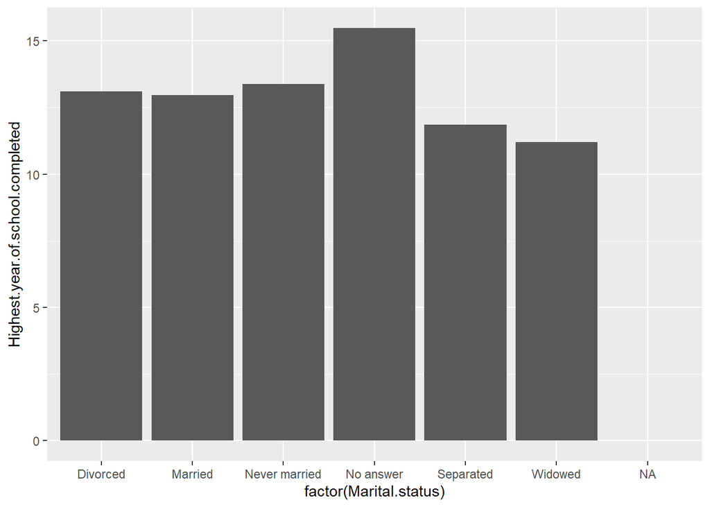

```r
ggplot(data, aes(x = factor(Marital.status), y = Highest.year.of.school.completed)) +
  stat_summary(fun = "mean", geom = "bar")
```

#### 2.

```r
data %>% group_by(Marital.status) %>% summarize(avgMaritalStatus = mean(Highest.year.of.school.completed,na.rm=TRUE))##Find the average of each group
```

```
## # A tibble: 7 x 2
##   Marital.status avgMaritalStatus
## * <chr>                     <dbl>
## 1 Divorced                   13.1
## 2 Married                    13.0
## 3 Never married              13.4
## 4 No answer                  15.5
## 5 Separated                  11.9
## 6 Widowed                    11.2
## 7 <NA>                      NaN
```

```r
newData <- data %>% filter((Marital.status == "Divorced" & Highest.year.of.school.completed > 13.1) | (Marital.status == "Married" & Highest.year.of.school.completed > 13.0) | (Marital.status == "Never married" & Highest.year.of.school.completed > 13.4) | (Marital.status == "No answer" & Highest.year.of.school.completed > 15.5) | (Marital.status == "Separated" & Highest.year.of.school.completed > 11.9) | (Marital.status == "Widowed" & Highest.year.of.school.completed > 11.2))
str(newData)
```

```
## tibble [28,146 x 9] (S3: tbl_df/tbl/data.frame)
##  $ Gss.year.for.this.respondent    : num [1:28146] 1972 1972 1972 1972 1972 ...
##  $ Respondent.id.number            : num [1:28146] 1 4 6 8 16 17 19 20 25 32 ...
##  $ Number.of.hours.worked.last.week: chr [1:28146] "Not applicable" "Not applicable" "Not applicable" "Not applicable" ...
##  $ Marital.status                  : chr [1:28146] "Never married" "Married" "Never married" "Never married" ...
##  $ Highest.year.of.school.completed: num [1:28146] 16 17 14 16 14 14 17 14 16 14 ...
##  $ Political.party.affiliation     : chr [1:28146] "Ind,near dem" "Not str democrat" "Ind,near dem" "Ind,near dem" ...
##  $ Belief.in.life.after.death      : chr [1:28146] "Not applicable" "Not applicable" "Not applicable" "Not applicable" ...
##  $ General.happiness               : chr [1:28146] "Not too happy" "Not too happy" "Pretty happy" "Not too happy" ...
##  $ Ballot.used.for.interview       : chr [1:28146] "Not applicable" "Not applicable" "Not applicable" "Not applicable" ...
```

```r
View(newData)
```

#### 3.

Looking at the data of people who are considered “pretty happy” or very happy“, we found that the most popular marital status of this group of people are”Married“. Looking at the graph, it confirms this finding as well as show results where the least popular marital status is. For example, it looks like”separated" people were among the least happy. We disregard the “No answer” people because that doesn’t tell us any real life data. In addition, it confirms that “Never married” people are generally happier than “Divorced” or “Widowed” people. This is how the marital status is related to a person’s general happiness.

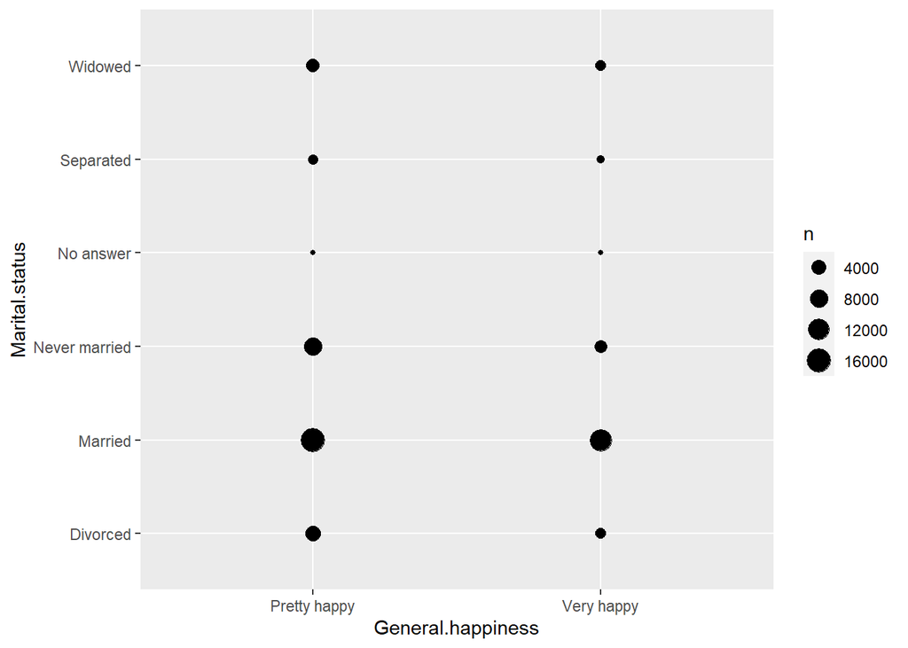

```r
data2 <- data %>% filter(General.happiness == "Very happy" | General.happiness == "Pretty happy")
ggplot(data2,aes(x=General.happiness,y=Marital.status)) + geom_count()
```

```r
tail(names(sort(table(data2$Marital.status))), 1)
```

```
## [1] "Married"
```

#### 4.

Political party affiliation does not affect the relationship between the marital status and general happiness of a person too much because in the graphs I found that regardless of political party, “Married” people were still the most popular marital status for happy people and separated people were still among the least happy. If I had to nit pick, it seems that the at each intensity of the political spectrum(ex. Strong, not strong) the democratic people seemed to be more populated in the happy graphs compared to Republicans, but it looks very close so we probably can’t conclude that as a fact, just a interesting observation. Another interesting finding is that, like the previous graph, these ones show that there are more people considered to be pretty happy than very happy, but the distributions of those are correlated evenly with the ones who are pretty happy too.Finally, we found that the political affiliation that was most popular among “hapy” people are not strong democrats which would help our case for our earlier statement saying it looks like democrats overall show as happy people compared to republican.

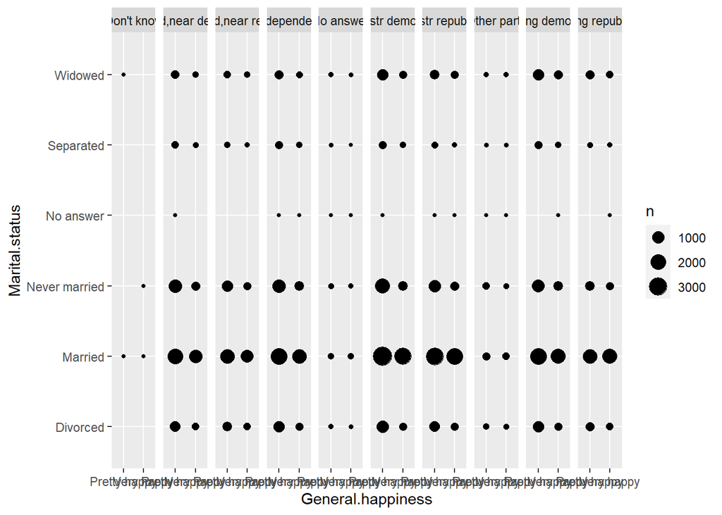

```r
data3 <- data %>% group_by(Political.party.affiliation) %>% filter(General.happiness == "Very happy" | General.happiness == "Pretty happy")
ggplot(data3,aes(x=General.happiness,y=Marital.status)) + geom_count() + facet_grid(cols = vars(Political.party.affiliation))
```

```r
tail(names(sort(table(data3$Political.party.affiliation))), 1)
```

```
## [1] "Not str democrat"
```

#### 5.

The marital status is somewhat affected by the person’s marital status as shown in the graphs below.The first one shows the average number of years completed per marital status and it shows that never married people have the highest average among those who answered the question. This is telling that the never married people probably have more time to complete more years while the married people don’t as much. It is interesting that the separated and widowed people have a slightly lower average than the other marital statuses. This could be because they are older (less need for more school years back then) or for some other reason. In the second graph, this tells us where the majority of people associate themselves for these 2 values. Looking at each marital status we can see the distribution of school years completed. For example, among married people, the most popular range of year of school completed are about 12-16 where as for widowed people, the most popular range of year of school completed are about 8-14. Finally, we filter for people who have over 13 years of school completed and we found that married is the most popular marital status among people with over 13 years of school completed.

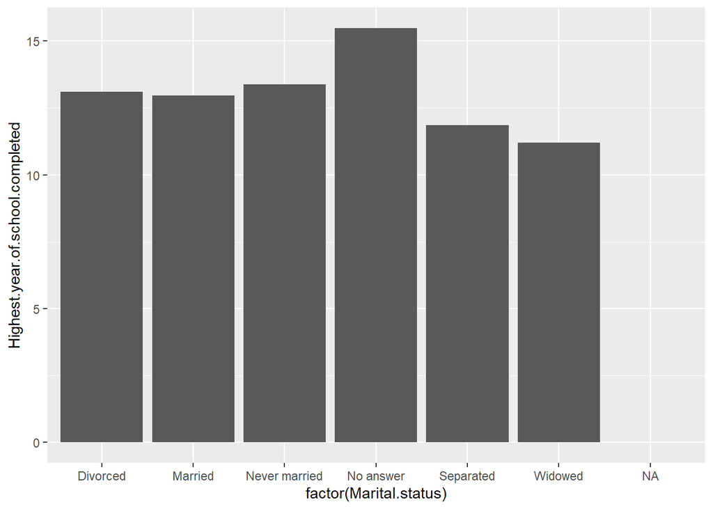

```r
ggplot(data,aes(x=factor(Marital.status),y=Highest.year.of.school.completed)) + stat_summary(fun = "mean", geom = "bar")
```

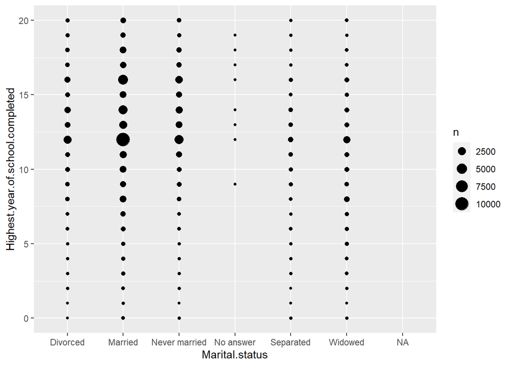

```r
ggplot(data,aes(x=Marital.status,y=Highest.year.of.school.completed)) + geom_count()
```

```r
data <- data %>% group_by(Marital.status) %>% filter(Highest.year.of.school.completed>13)
tail(names(sort(table(data$Marital.status))), 1)
```

```
## [1] "Married"
```

#### 6.

Next, I evaluated the potential correlation between one’s belief in life after death and their overall happiness. For this, I looked at the frequency and distributions of the level of happiness compared to the person’s beliefs in life after death or not. I found that the slight majority of people surveyed said that they did believe in life after death and that they were mostly pretty happy or very happy. People who said yes were also more likely to be not happy but that’s because the popular vote was yes. Looking at the sizes of happy vs not happy show that the ratio of happy and not happy for yes and no people are pretty close but with a slight edge to very happy people who believe in life after death. This group showed more people than other ratios of happiness.

```r
#work
data$Number.of.hours.worked.last.week <- as.numeric(as.character(data$Number.of.hours.worked.last.week))
group_by(data, General.happiness) %>% summarize(m = mean(Number.of.hours.worked.last.week,na.rm = TRUE))
```

```
## # A tibble: 6 x 2
##   General.happiness     m
## * <chr>             <dbl>
## 1 Don't know         50
## 2 No answer          46
## 3 Not applicable     42.8
## 4 Not too happy      41.0
## 5 Pretty happy       42.5
## 6 Very happy         42.8
```

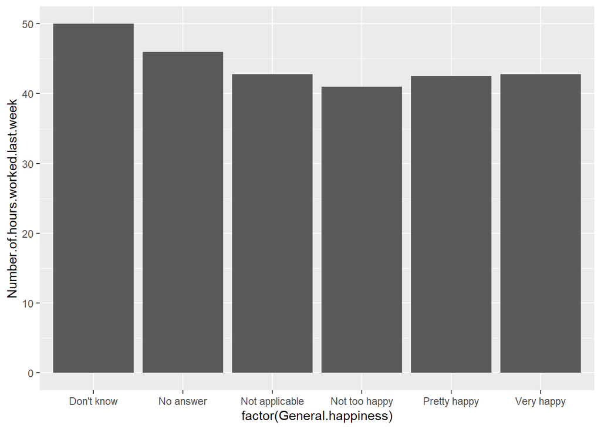

```r
ggplot(data, aes(x = factor(General.happiness), y = Number.of.hours.worked.last.week)) +
  stat_summary(fun = "mean", geom = "bar")
```

```r
tail(names(sort(table(data$Number.of.hours.worked.last.week))), 1)
```

```
## [1] "40"
```

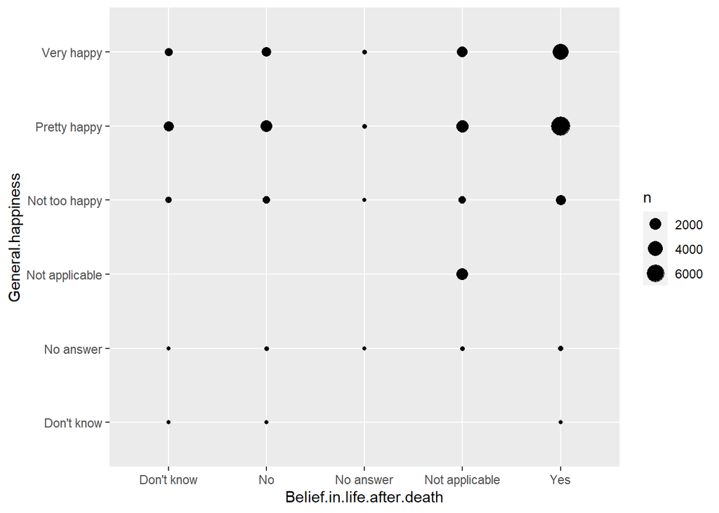

```r
#Belief
ggplot(data,aes(x=Belief.in.life.after.death,y=General.happiness)) + geom_count()
```

```r
tail(names(sort(table(data$Belief.in.life.after.death))), 1)
```

```
## [1] "Yes"
```